# Analysis of hepatocellular carcinoma data

Normalization with vsn

Author

Carlota de la Concepción Ruiz

## Contexto

Células de hepatocarcinoma celular se han tratado con 5’-metiltioadenosina (MTA) a diferentes concentraciones y se han tomado muestras a las 24 y a las 48 horas para cada una de las tres réplicas biológicas. Así, tenemos 18 muestras. Se van a comparar las proteínas presentes al mismo tiempo entre diferentes concentraciones para ver con el objetivo de entender a qué rutas metabólicas y funciones afecta la presencia de MTA a diferentes concentraciones.

### Resumen del tratamiento de los datos

El análisis de datos reales, donde no se conoce el resultado final, se ha llevado a cabo de la misma manera. Se han analizado las métricas de PRONE y NAguideR para seleccionar los métodos de normalización e imputación de valores MAR y MNAR. Para estos últimos, como se ha indicado, no sirven las métricas de NAguideR. Sin embargo, como se ha observado, los métodos que peor evaluados aparecen según estas métricas, en el benchmarking realizado anteriormente tienden a ser los óptimos para los valores MNAR.

## Tratamiento de los datos

### Preprocesamiento de los datos crudos y obtención de métodos de normalización e imputación

En primer lugar se ha comprobado que los datos exportados de Spectronaut corresponden con el formato que el paquete NADIA gestiona. Se observa que los nombres de las columnas son correctos. Sin embargo, las condiciones están indicadas como: “24H 0MTA”, “24H 10MTA”… Y por ello, se ha de modificar la columna de condiciones cambiando el espacio por una barra baja.

```r
tsv_original <- "../../../20260916_165940_20250307_PLC_MTA_Report.tsv"
tsv_nadia <- "../../../MTA_Report_for_NADIA.tsv"

datos_mta <- read.delim(tsv_original, stringsAsFactors = FALSE)

datos_mta$R.Condition <- gsub(" ", "_", datos_mta$R.Condition)

datos_mta$R.Condition <- gsub("24H", "h24", datos_mta$R.Condition)

datos_mta$R.Condition <- gsub("48H", "h48", datos_mta$R.Condition)

write.table(datos_mta, file = tsv_nadia, sep = "\t", row.names = FALSE, quote = FALSE)
```

Se ha automatizado el proceso de selección de métodos de normalización e imputación de datos (para valores ausentes aleatorios). Esta funcion, automáticamente guarda la salida de las funciones que evaluan las métricas en la carptea donde se encuentran los datos

```r
source("./fun_norm_imp_methods.R")
norm_imp_methods_MTA <- obtaining_norm_imp_methods(".","../../../MTA_Report_for_NADIA.tsv",
c("h24_0MTA","h24_10MTA", "h24_50MTA", "h48_0MTA","h48_10MTA", "h48_50MTA"))
```

Si bien el proceso de selección de método de normalización e imputación de los datos, se ha automatizado, se confirma de manera manual que el método seleccionado es el óptimo. Así, en la Figure 1 se puede observar que el mejor método de imputación de valores es vsn a pesar de que al observar la Table 1 el valor medio final de posicion es igual para vsn que para cycloess, dado que la varianza explicada por el primer componente es mayor para vsn, este será el método de normalización seleccionado.

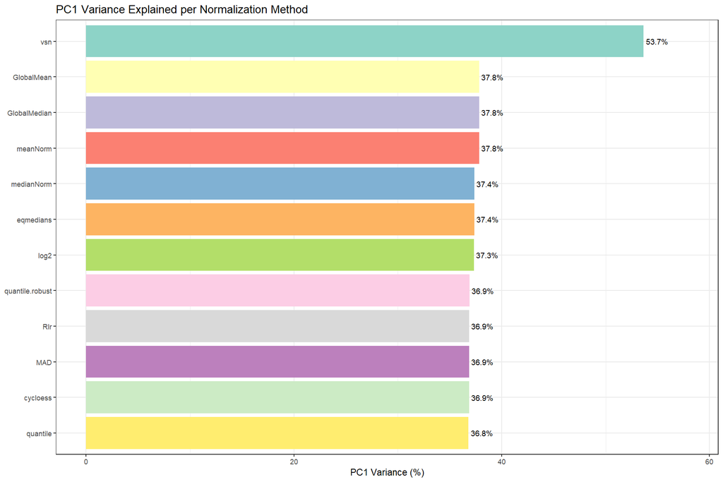

Figure 1: Gráfico de barras de la varianza explicada por el componente principal 1 de cada una de los métodos de normalización de datos

| **Método** | **Rank PCV** | **Rank PMAD** | **Rank PEV** | **Rank Cor** | **Rank Sep** | **Rank Final** |
| --- | --- | --- | --- | --- | --- | --- |
| vsn | 1 | 1 | 1 | 1 | 12 | 3.2 |
| cycloess | 2 | 3 | 2 | 2 | 7 | 3.2 |
| log2 | 4 | 8 | 9 | 3 | 4 | 5.6 |
| eqmedians | 6 | 6 | 5 | 6 | 6 | 5.8 |
| medianNorm | 5 | 7 | 6 | 7 | 5 | 6.0 |
| Rlr | 3 | 5 | 3 | 9 | 11 | 6.2 |
| GlobalMedian | 10 | 10 | 12 | 4 | 1 | 7.4 |
| quantile | 8 | 4 | 4 | 12 | 10 | 7.6 |
| quantile.robust | 9 | 2 | 8 | 11 | 9 | 7.8 |
| MAD | 7 | 9 | 7 | 10 | 8 | 8.2 |
| GlobalMean | 12 | 11 | 11 | 5 | 3 | 8.4 |
| meanNorm | 11 | 12 | 10 | 8 | 2 | 8.6 |

### Selección del método de imputación para valores MNAR

En cuanto a la selección del método de imputación de datos MAR, el más adecuado parece ser bpca (Table 2). Se analizan las gráficas una a una para ver la robustez de dicho orden.Para el caso de el NRMSE (Figure 2 (a)), muestra los valores más bajos, ligeramente inferior a los valores de Impseq e Impseqrob. Para la métrica SOR (Figure 2 (b)), el mínimo valor lo obtiene la métrica Impseqrob, seguido por bpca y este por Impseq. En relacion con el PSS(Figure 2 (c)), el método que menor puntuacion obtiene es missForest, obteniendo un valor inferior a la mitad del siguiente método. Estos siguientes métodos son bpca e Impseq. Finalmente, para la métrica ACC OI (Figure 2 (d)), los métodos bpca, Impseq, ImpseqRob y missForest obtienen la misma puntuacion (otros métodos también pero no destacan en otras métricas).

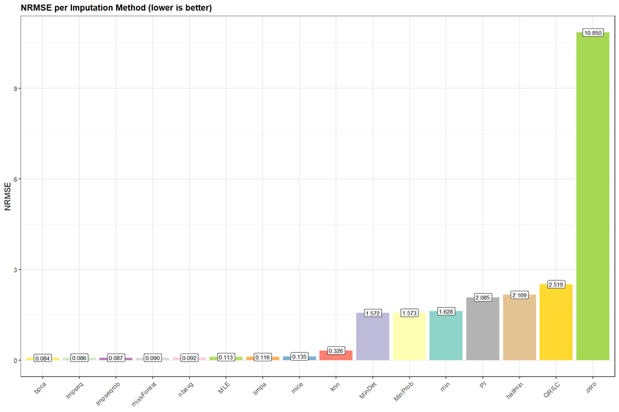

(a) NRMSE

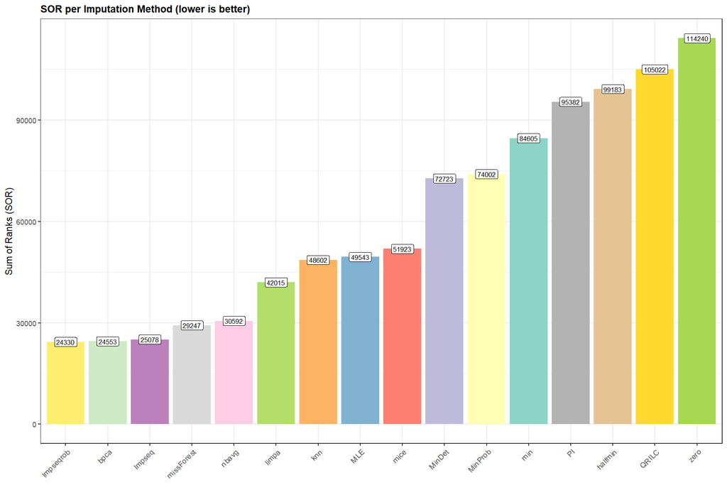

(b) SOR

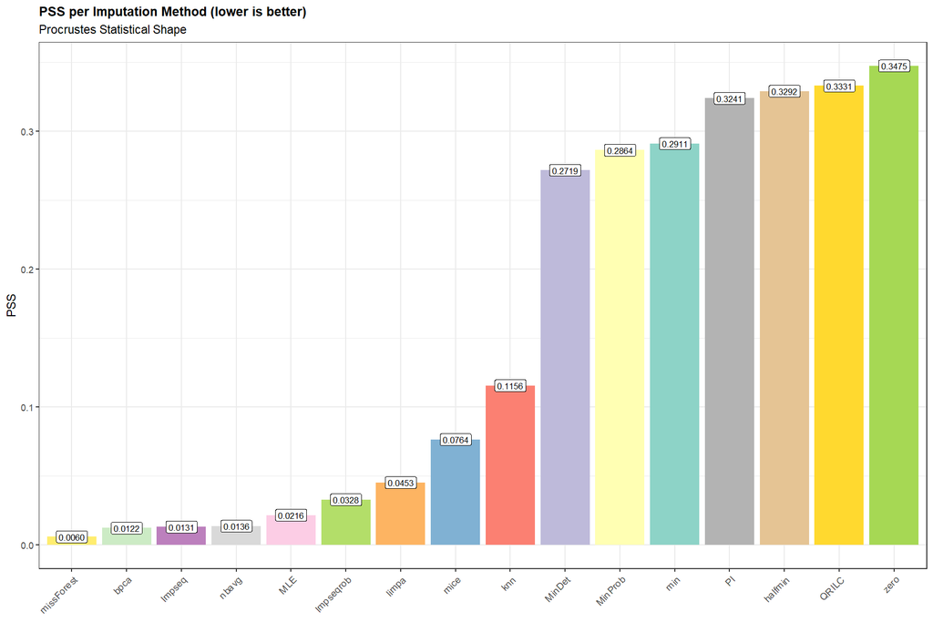

(c) PSS

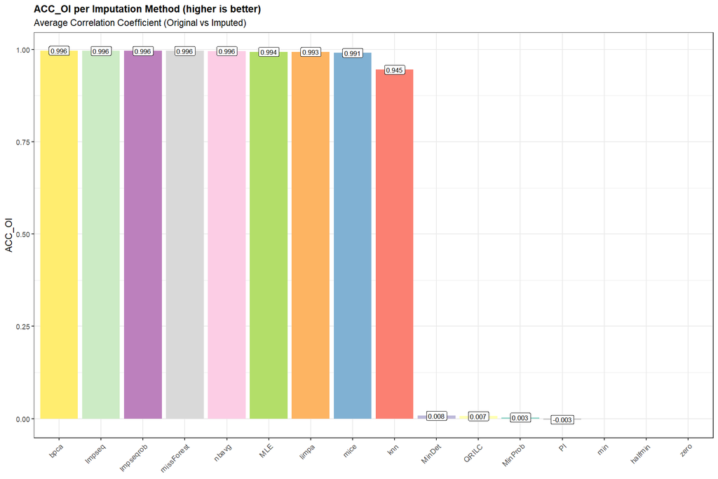

(d) ACC OI

Figure 2: Gráficos de las métricas utilizadas por NAguideR para evaluar la imputación de valores ausentes por causas aleatorias.

Para calcular el ranking se calcula la media entre el número de metricas de evaluación que toman valor.

Table 2: Tabla de métricas NAguideR. Los valores observados son la posicion dendiente de la métrica.

[output not shown]

Según la Table 2 y como se ha indicado anteriormente, la métrica que parece más optima es bcpa, sin embargo, esto se ve sesgado por la ordenacion por orden alfabético cuando los valores métricos coinciden. Tras haber analizado las gráficas junto a la tabla, se determina que bpca será el método de imputación a utilizar debido a que, a pesar de tomar la primera posicion en ACC OI por ser el primero en orden alfabético, toma las primeras posiciones en otras ocasiones por tener métricas optimas y realmente inferiores a los demás (NRMSE).

Finalmente, se selecciona el método zero para imputar valores de tipo MNAR ya que, se ha observado que se obtienen menos resultados falsos al imputar los valores MAR y MNAR diferenciandolos que utilizando el mismo método para ambos tipos de ausencias. Por ello, dado que las métricas NAguider solo son capaces de evaluar los métodos MAR, este se selecciona como se ha indicado y el método MNAR más optimo, tiende a ser el que menor posicion obtiene segun estas mismas métricas.